# MR-ToF analysis

Created on 07 September 2019 for the ISOLTRAP experiment

- V1.1 (09 June 2020): Maximum likelihood estimation and peak finder are now simplified and only based on SciPy and the CERN-ROOT6 minimizer via the iminuit package (→ great performance)

@author: Jonas Karthein  
@contact: jonas.karthein@cern.ch  
@license: MIT license

### References

[1](https://doi.org/10.1038/nature12226) F. Wienholtz, et al. Nature 498, 346 (2013).  
[2](https://doi.org/10.1103/PhysRevLett.120.232501) M. Mougeot, et al. Phys. Rev. Lett. 120, 232501 (2018).  
[3](https://doi.org/10.1088/1674-1137/41/3/030002) W.J. Huang, et al. Chinese Phys. C 41, 030002 (2017).

### Application

The code was used to analyse data for the following publication:

[4] M. Mougeot, et al. in preparation (2019)

### Introduction

The following code was written to reconstruct raw, unbinned multi-reflection time-of-flight (MR-ToF) data taken by a MagnetTOF electron multiplier particle detector by ETP Ion Detect [5](https://www.etp-ms.com/technology/new_detectors) and using the MPANT software [6](https://www.fastcomtec.com/products/software/) for data aquisition. Besides a regular spectral time-of-flight (ToF) analysis with unbinned, maximum likelihood estimation and diverse cuts, the code includes a more advanced automated statistical cutting tool for ToF-drift detection based on rolling averaging. Finally, a mass value can be calculated from the fitted peaks by utilizing the Atomic Mass Evaluation (AME16) database [3](https://doi.org/10.1088/1674-1137/41/3/030002).

### Required software and libraries

The following code was written in Python 3.7. The required libraries are listed below with a rough description for their task in the code. It doesn't claim to be a full description of the library.

- pandas (data storage and calculation)
- numpy (calculation)
- matplotlib (plotting)
- scipy (chi square fitting)
- configparser (configuration file processing)
- jupyter (Python notebook environment)
- iminuit (Python interface to the C++ Minuit2 library of ROOT6 → used for maximum likelihood estimation)

All packages can be fetched using pip:

```python
!pip3 install --user pandas numpy matplotlib scipy configparser jupyter iminuit
```

```python
%config InlineBackend.figure_format ='retina'

from bin.load_lst import *
import pandas as pd
import numpy as np
import pickle, os

# list of raw data files to reconstruct
lst_files = ['data/test_run455.lst',    # nrevs = x, bg = x ms, cycles = x, test mode
             'data/test_run456.lst']    # nrevs = x, bg = x ms, cycles = x, test mode

# open preanalyzed dataset if existing, raw conversion takes LONG!
if os.path.isfile('data/mr-tof-data.p'):
    df = pickle.load(open('data/mr-tof-data.p','rb'))
else:
    df = process_lst(lst_files)
    pickle.dump(df, open('data/mr-tof-data.p','wb'))
```

# File selection

Single or multiple files can be selected for the analysis. For the combination of two files add (further files can be added in the same fashion):

`file2 = lst_files[i]`  
`file2 = os.path.splitext(os.path.basename(file))[0]`  
`file_df2 = df[file2]`  
`file_df2.sweep = file_df2.sweep + file_df.sweep.max() + 1`  
`file_df = file_df.append(file_df2, ignore_index = True)`  
`file = file+file2`

```python
file = lst_files[0]
file = os.path.splitext(os.path.basename(file))[0]

file_df = df[file]

print('File "{}" selected'.format(file))
```

```
File "test_run455" selected
```

# Analysis cuts

A cut by the number of ions per sweep (= injection) can be performed by changing the the variable `z_cut <= number_of_max_ions`. The ToF window can be selected by adjusting the variable `tof_window = [tof_min, tof_max]` (leave empty list `[]` for no cut). One/multiple sweep windows can be removed via the variable `sweep_windows = [[sweep_min_1, sweep_max_1], [sweep_min_2, sweep_max_2], ...]` by adding windows to the list of lists (leave emplty list of lists `[[]]` for no cut).

```python
z_cut = 5              # z_cut = number_of_max_ions
tof_window = []        # tof_window = [tof_min, tof_max]
sweep_windows = [[]]   # sweep_windows = [[sweep_min_1, sweep_max_1], [sweep_min_2, sweep_max_2], ...]

# z-class cut
file_df = file_df[file_df.sweep.isin(file_df.sweep.value_counts()[file_df.sweep.value_counts() <= z_cut].index)]
# tof-window cut
if tof_window != []:
    file_df = file_df[(file_df.tof >= tof_window[0]) & (file_df.tof <= tof_window[1])]
# sweep-windows cut
if sweep_windows != [[]]:
    for sweep_window in sweep_windows:
        file_df = file_df[(file_df.sweep < sweep_window[0]) | (file_df.sweep > sweep_window[1])]
```

# General display

In the following, the data is displayed in a 2D plot (time of flight (ToF) vs sweep). Histograms of the x and y projections are created in order to better display the measured peaks and count rate. This allows to find peaks using the ToF distribution projection. The important variables to adjust for optimal peak finding are `peak_threshold` (adjusting the minimum threshold as ratio to the dominant peak), `peak_min_distance` (adjusting the minimum distance between peaks), `peak_min_height` (adjusting the minimum height of peaks) and `peak_width_inbin` (tuple of (min,max) with of a peak, given in bins). The peak is found using the SciPy peak finder mainly to find the peaks and their bases ranges. Using this information, an exponentially tailed Gaussian is fitted to find the optimal peak position even for asymmetric peaks.  
Additionally, a rolling average analysis of the dominant peak can be performed in order to automatically (= maximally unbiased) find ToF drifts and to exclude them from the data set. The rolling average can be adjusted by changing the number of summarized events in `rolling_nr`.

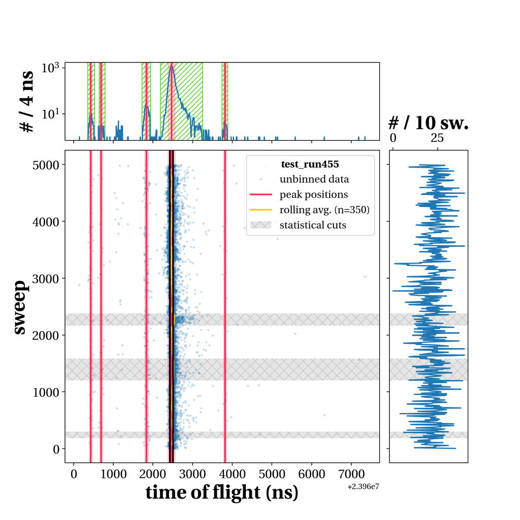

```python
import matplotlib.pyplot as plt
import matplotlib as mpl
import peakutils
from scipy.signal import find_peaks
from scipy import stats

# activate interactive matplotlib plot
%matplotlib notebook

# Utopia LaTeX font with greek letters
mpl.rc('font', family='serif', serif='Linguistics Pro')
mpl.rc('text', usetex=False)
mpl.rc('mathtext', fontset='custom',
       rm='Linguistics Pro',
       it='Linguistics Pro:italic',
       bf='Linguistics Pro:bold')

# main figure with x and y projections
fig, ((ax_x, blank),(ax_0, ax_y)) = plt.subplots(2,2,sharex='col',sharey='row', figsize=(9,9),
                                                 gridspec_kw={'height_ratios':[1,4],
                                                             'width_ratios':[4,1],
                                                             'hspace': 0.05,
                                                             'wspace':0.05})
# remove unused subplots
blank.remove()

# faster binning for projections than histograms -> necessary in order to automatically find peaks
x_proj = file_df.tof.value_counts(bins=500).sort_index()
y_proj = file_df.sweep.value_counts(bins=500).sort_index()

# main plotting
file_df.plot(x='tof', y='sweep', style='o', alpha=0.15, ms=2, ax=ax_0, label='unbinned data')
ax_x.semilogy(x_proj.index.mid.to_numpy(), x_proj.to_numpy())
ax_y.plot(y_proj.to_numpy(), y_proj.index.mid.to_numpy())

# axis labels
ax_0.set_xlabel('time of flight (ns)', fontsize=24, fontweight='bold')
ax_0.set_ylabel('sweep', fontsize=24, fontweight='bold')
# ax_0.ticklabel_format(useOffset=False, style='plain')
ax_x.set_ylabel('# / 4 ns', fontsize=24, fontweight='bold')
ax_y.set_xlabel('# / 10 sw.', fontsize=24, fontweight='bold')
ax_y.xaxis.set_ticks_position('top')
ax_y.xaxis.set_label_position('top')

# peak finder -> !!! ADJUST HERE !!!
#
#
#
peak_threshold = 0.002
peak_min_distance = 5
peak_min_height = 4
peak_width_inbins = (3,70)
#
#
#
x_proj_peaks, peaks_info = find_peaks(x_proj, threshold=peak_threshold,
                                     distance=peak_min_distance,
                                     height=peak_min_height,
                                     width=peak_width_inbins)

# get the highest peak to perform the rolling average
highest_peak = peaks_info['peak_heights'].argmax()
x_proj_peak_ind = []

for i in range(len(x_proj_peaks)):
    # get the peak bases ranges from the peak finder
    left = x_proj.index.mid[peaks_info['left_bases'][i]]
    right = x_proj.index.mid[peaks_info['right_bases'][i]]

    # calculate the median (more accurate due to asym. tails) of the data in the peak ranges
    # better value for the actual peak center than the simple highest point in peak
    peak_pos = file_df.tof[(file_df.tof < right) &
                          (file_df.tof > left)].median()
    peak_std = file_df.tof[(file_df.tof < right) &
                          (file_df.tof > left)].std()

    # estimate the mean and sigma from a Gaussian with exponential tail (accounting for asym. peaks)
    try:
        peak_fit = stats.exponnorm.fit(file_df.tof[(file_df.tof < peak_pos+peak_std) &
                                                   (file_df.tof > peak_pos-peak_std)],
                                       loc=peak_pos)
        # update peak position if a fit was possible
        peak_pos = peak_fit[1]
    except:
        pass

    # save peak position
    x_proj_peak_ind.append(peak_pos)

    # plot the peak positions, stds and ranges
    ax_x.axvline(peak_pos, c='#FF2D55', linewidth=2)
    ax_x.axvspan(left, right, facecolor='none', hatch='////', edgecolor='#61D935', label='peak range')
    ax_x.axvspan(peak_pos-peak_std, peak_pos+peak_std, color='#FF2D55', alpha=0.2)
    ax_0.axvline(peak_pos, c='#FF2D55', linewidth=2,
                 label='peak positions' if peak_pos == x_proj_peak_ind[0] else "")
    ax_0.axvspan(peak_pos-peak_std, peak_pos+peak_std, color='#FF2D55', alpha=0.2)

    # calculate rolling avg for the most abundant peak to find outliers
    if i == int(highest_peak):
        rolling_nr = 350
        # calculates the standard deviation of the rolling average
        rolling_std = file_df.tof[(file_df.tof < peak_pos+300) &
                    (file_df.tof > peak_pos-300)].rolling(rolling_nr).mean().std()
        # calculates the rolling average and shifts it by half of rolling_nr for proper display
        rolling_ser = file_df.tof[(file_df.tof < peak_pos+300) &
                    (file_df.tof > peak_pos-300)].rolling(rolling_nr).mean().shift(-int(rolling_nr/2))

        # plotting the rolling average
        ax_0.plot(rolling_ser.to_numpy(), file_df.sweep[(file_df.tof < peak_pos+300) &
                    (file_df.tof > peak_pos-300)].to_numpy(), '-', lw=2, c='#FFCC00',
                  label='rolling avg. (n={})'.format(rolling_nr))
        ax_0.axvline(peak_pos+2*rolling_std, c='k', linewidth=2)
        ax_0.axvline(peak_pos-2*rolling_std, c='k', linewidth=2)

        sweep_outs = []
        sweep_ins = []
        # find positions where rolling avg crosses +/-2 sigma of the main peak outwards to exclude these files
        for sweep_out in (file_df.sweep[(file_df.tof < peak_pos+300) & (file_df.tof > peak_pos-300)]
                              [((rolling_ser.fillna(value=peak_pos) - (peak_pos+2*rolling_std) > 0) &
                                 (rolling_ser.fillna(value=peak_pos).shift() - (peak_pos+2*rolling_std) < 0)) |
                               ((rolling_ser.fillna(value=peak_pos) - (peak_pos-2*rolling_std) < 0) &
                                (rolling_ser.fillna(value=peak_pos).shift() - (peak_pos-2*rolling_std) > 0))]
                          .to_numpy()):
            sweep_outs.append(sweep_out)
        # find positions where rolling avg crosses +/-2 sigma of the main peak inwards to exclude these files
        for sweep_in in (file_df.sweep[(file_df.tof < peak_pos+300) & (file_df.tof > peak_pos-300)]
                              [((rolling_ser.fillna(value=peak_pos) - (peak_pos+2*rolling_std) < 0) &
                                (rolling_ser.fillna(value=peak_pos).shift() - (peak_pos+2*rolling_std) > 0)) |
                               ((rolling_ser.fillna(value=peak_pos) - (peak_pos-2*rolling_std) > 0) &
                                (rolling_ser.fillna(value=peak_pos).shift() - (peak_pos-2*rolling_std) < 0))]
                          .to_numpy()):
            sweep_ins.append(sweep_in)
        # plot areas where rolling average is outside the +/- 2 sigma band
        for i in range(len(sweep_outs)):
            ax_0.axhspan(sweep_outs[i], sweep_ins[i], color='k', alpha=0.1, linewidth=0, hatch='XX',
                         label='statistical cuts' if i == 0 else "")
            ax_y.axhspan(sweep_outs[i], sweep_ins[i], color='k', alpha=0.1, linewidth=0, hatch='XX')

# standardized figure parameters
ax_0.tick_params(labelsize=16)
ax_x.tick_params(labelsize=16)
ax_y.tick_params(labelsize=16)
lg = ax_0.legend(title=file, loc='upper right', fontsize=13)
plt.setp(lg.get_title(),fontsize=13,fontweight='bold')    # legend title bold
plt.savefig('data/{}-analysis.pdf'.format(file),bbox_inches='tight',pad_inches=0)
plt.show()
```

# Statistical cut

Cut away all sweeps in which the rolling average is outside the +/- 2 $\sigma$ band. These events were found at ISOLTRAP to be caused by electronic malfunction of the high-voltage switch or the mirror electrodes and can usually also be correlated to drops in count rate (= y projection).

```python
cut_df = file_df

for i in range(len(sweep_outs)):
    cut_df = cut_df[(cut_df.sweep < sweep_outs[i]) | (cut_df.sweep > sweep_ins[i])]
```

# Gaußian fits with varying range

Gaußian fits are performed for all found peaks using unbinned maximum likelihood estimation. The choice for Gaußian models instead of fancier models - such as exponential Gaußians or high-order polynomials - was made because the unsymmetric tail towards later times has not been physically modeled so far. The fit range is varying to avoid any bias towards later times due to the non-Gaußian peak shape in the tail. Further models can, however, easily be added if wanted.

```python
from scipy.stats import norm
from iminuit import Minuit
import numpy as np

def MLE_gauss(mean, sig):
    '''Negative log likelihood function for (n=1)-dimensional Gaussian distribution.'''
    return( -np.sum(norm.logpdf(x=data_t,
                    loc=mean,
                    scale=sig)) )

def Start_Par(data):
    '''Starting parameter based on simple mean of 1D numpy array.'''
    return(np.array([data.mean(),  # meanx
                     data.std()])) #rho


# defining fit ranges
fit_ranges = [40, 45, 50, 55, 60, 65, 70, 75, 80, 85, 90, 95, 100, 110, 120, 130, 140, 160, 180]
results_df_dict = {}

# fitting for each fit range
for i in range(len(x_proj_peak_ind)):
    results_df_dict['peak_{}'.format(i+1)] = []
    for fit_range in fit_ranges:
        # applying fit range by cutting the data frame
        fit_df = cut_df.tof[(cut_df.tof < x_proj_peak_ind[i] + fit_range) &
                            (cut_df.tof > x_proj_peak_ind[i] - fit_range)]
        data_t = fit_df.to_numpy()
        # fit for all peaks and different ranges
        r = Minuit(MLE_gauss, mean=Start_Par(data_t)[0], sig=Start_Par(data_t)[1],
                   error_mean=0.1, error_sig=0.1,
                   limit_mean=(None, None), limit_sig=(None, None),
                   errordef=0.5)   # for negative log-likelihood functions
        r.migrad() # finds minimum of mle function
        r.hesse()  # computes errors

        results_df_dict['peak_{}'.format(i+1)].append([r.values['mean'], r.errors['mean'] , r.values['sig'], r.errors['sig']])

        print('\nFit results for peak {} in range {} ns:'.format(i, fit_range))
        for p in r.parameters:
            print('    {} (sym) = {:3.1f} +/- {:3.1f}'.format(p, r.values[p], r.errors[p]))
# save fit results in dataframe
for key in results_df_dict.keys():
    results_df_dict[key] = pd.DataFrame(results_df_dict[key], columns=['mean_t', 'mean_t_unc', 'sigma', 'sigma_unc'])
results_df = pd.concat(results_df_dict, axis=1).set_index(pd.Series(fit_ranges))

results_df.to_csv('data/{}-fits-summary.csv'.format(file))
```

```
Fit results for peak 0 in range 40 ns:
    mean (sym) = 23960431.9 +/- 3.2
    sig (sym) = 18.1 +/- 2.3

Fit results for peak 0 in range 45 ns:
    mean (sym) = 23960432.0 +/- 3.4
    sig (sym) = 19.9 +/- 2.4

Fit results for peak 0 in range 50 ns:
    mean (sym) = 23960433.3 +/- 3.8
    sig (sym) = 24.5 +/- 2.7

Fit results for peak 0 in range 55 ns:
    mean (sym) = 23960433.3 +/- 3.8
    sig (sym) = 24.5 +/- 2.7

Fit results for peak 0 in range 60 ns:
    mean (sym) = 23960432.2 +/- 4.1
    sig (sym) = 27.5 +/- 2.9

Fit results for peak 0 in range 65 ns:
    mean (sym) = 23960432.2 +/- 4.1
    sig (sym) = 27.5 +/- 2.9

Fit results for peak 0 in range 70 ns:
    mean (sym) = 23960433.7 +/- 4.5
    sig (sym) = 31.4 +/- 3.2

Fit results for peak 0 in range 75 ns:
    mean (sym) = 23960435.1 +/- 4.6
    sig (sym) = 32.7 +/- 3.3

Fit results for peak 0 in range 80 ns:
    mean (sym) = 23960435.1 +/- 4.6
    sig (sym) = 32.7 +/- 3.3

Fit results for peak 0 in range 85 ns:
    mean (sym) = 23960435.1 +/- 4.6
    sig (sym) = 32.7 +/- 3.3

```

[output cut: 324 more lines]

```
Fit results for peak 4 in range 130 ns:
    mean (sym) = 23963810.4 +/- 8.3
    sig (sym) = 40.6 +/- 5.9

Fit results for peak 4 in range 140 ns:
    mean (sym) = 23963810.4 +/- 8.3
    sig (sym) = 40.6 +/- 5.9

Fit results for peak 4 in range 160 ns:
    mean (sym) = 23963816.5 +/- 10.0
    sig (sym) = 50.2 +/- 7.1

Fit results for peak 4 in range 180 ns:
    mean (sym) = 23963810.3 +/- 11.4
    sig (sym) = 58.6 +/- 8.1
```